# Escolha Intertemporal - Método Bisection

Considere o problema de maximização: $$ \max_{0\le c\le y}\left\{ u(c) + \beta u(y-c) \right\} $$ em que $$ u(c) = \frac{c^{1-\delta} - 1}{1 - \delta}. $$

Note que $0 \le c \le y$, pois: \begin{align} c_1 &= c \ge 0 \\ c_2 &= y - c_1 \ge 0 \end{align}

A condição necessária para o ótimo (interior) é: $$ u'(c) = \beta u'(y-c) \iff u'(c) - \beta u'(y-c) = 0 $$

- Seja $F(c) = u'(c) - \beta u'(y-c)$.
- Quer-se computar $c^*$ tal que $F(c^*) = 0$.

**Observação 1.** Note que $F(0) = \infty$ e $F(y) = -\infty < 0$. Como $F(\cdot)$ é contínua e estritamente decrescente, existe uma e somente uma raíz para $F(c) = 0$.

- $u'(c) = c^{-\delta}\ \implies\ F(c) = c^{-\delta} - \beta(y-c)^{-\delta}$
- $u''(c) = -\delta c^{-\delta-1} < 0$
- $F'(c) = u''(c) + \beta u''(y-c) < 0$

```python
# Importando módulos para trabalhar com matrizes e criar gráficos
import numpy as np
import matplotlib.pyplot as plt


# Definindo os parâmetros
beta, delta = .9, .5
y = 1  # Limite superior de y

n_c = 50
c_grid = np.linspace(0, y, n_c)  # Grid do consumo: entre 0 e a dotação y


# Definindo a função F(c)
def F(x):
    return x**(-delta) - beta * (y-x)**(-delta)


# Calculando os ótimos interiores por CPO para cada nível de consumo no c_grid
CPO = np.zeros(n_c)  # grid do consumo vazio

for i in range(n_c):
    CPO[i] = F(c_grid[i])

print(CPO)
```

```
[            inf  6.09067333e+00  4.03079802e+00  3.11256756e+00
  2.56085145e+00  2.18073443e+00  1.89699704e+00  1.67364021e+00
  1.49097903e+00  1.33721587e+00  1.20478699e+00  1.08858446e+00
  9.85012322e-01  8.91450687e-01  8.05934332e-01  7.26951142e-01
  6.53310767e-01  5.84056195e-01  5.18402420e-01  4.55692766e-01
  3.95366954e-01  3.36937142e-01  2.79969449e-01  2.24069247e-01
  1.68869017e-01  1.14017885e-01  5.91721374e-02  3.98611507e-03
 -5.18970530e-02 -1.08855459e-01 -1.67299823e-01 -2.27687126e-01
 -2.90537571e-01 -3.56456408e-01 -4.26162909e-01 -5.00529867e-01
 -5.80638951e-01 -6.67860437e-01 -7.63971523e-01 -8.71337849e-01
 -9.93202819e-01 -1.13417003e+00 -1.30105273e+00 -1.50447424e+00
 -1.76215595e+00 -2.10650161e+00 -2.60521300e+00 -3.43371778e+00
 -5.28963703e+00            -inf]
```

```
C:\Users\fhnis\AppData\Local\Temp/ipykernel_24488/2169520025.py:16: RuntimeWarning: divide by zero encountered in double_scalars
  return x**(-delta) - beta * (y-x)**(-delta)
```

```
C:\Users\fhnis\AppData\Local\Temp/ipykernel_24488/631980554.py:4: RuntimeWarning: invalid value encountered in multiply
  ax.plot(c_grid, CPO*0, "r")  # linha horizontal em vermelho
```

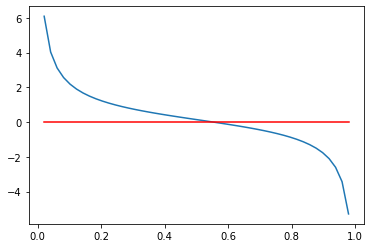

```python
# Plotando o gráfico da função
fig, ax = plt.subplots()
ax.plot(c_grid, CPO) # Função F(c)
ax.plot(c_grid, CPO*0, "r")  # linha horizontal em vermelho
plt.show()
```

Queremos encontrar a solução, ou seja, o valor de $c$ que faz $F(c)$ mais se aproximar de 0. Para isso, trabalharemos com o avalor absoluto de $F(c)$.

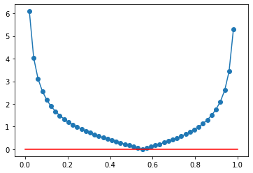

```python
# Plotando F(c) em valores absolutos
fig, ax = plt.subplots()
ax.plot(c_grid, abs(CPO), "-o") # Função F(c)
ax.plot(c_grid, [0 for i in range(n_c)], "r")  # forma alternativa de criar série de 0 de tamanho n_c
plt.show()
```

```python
# Encontrando o valor de c que mais se aproxima de 0
print("\n")  # Pulando 1 linha
print("Grid optimization returned solution F(c) =", round(min(abs(CPO)), 5), end=" ")  # end=" " espaço ao invés de pular linha

ind = np.argmin(abs(CPO))  # Índice de c que minimiza F(c) em valores absolutos
print("at c =", round(c_grid[ind], 5))
print("\n")  # Pulando 1 linha
```

```
Grid optimization returned solution F(c) = 0.00399 at c = 0.55102
```

## Otimização contínua

1. Definir intervalo iniciail com limites inferior e superior: $[c_L, c_H]$
2. Calcular $F(c_M)$ para o ponto médio deste intervalo, $c_M \equiv \frac{c_L + c_H}{2}$
3. Se $F(c_M) \approx 0$, paro. Caso contrário, se
   - $F(c_M) > 0$, então a raiz está acima do ponto médio e, portanto, atualizo $c_L \equiv c_M$
   - $F(c_M) < 0$, então a raiz está abaixo do ponto médio e, portanto, atualizo $c_H \equiv c_M$

     e retorno ao passo 2 com novo intervalo $[c_L, c_H]$.

```python
# Definindo intervalo inicial
c_L, c_H = 0, y

# Definindo norma e tolerância para convergência
norm = 1  # valor arbitrário para entrar no looop
tol = 1e-5

# Realizando as repetições de cálculo de F(c_M) até ser próximo de 0
while norm > tol:
    print("Intervalo atual = [", round(c_L, 4), ",", round(c_H, 4), "]", end=", ")
    c_M = (c_L + c_H) / 2
    CPO_M = F(c_M)
    norm = abs(CPO_M)  # Norma aqui é o valor absoluto da CPO no ponto médio
    print("com ponto médio c_M =", round(c_M, 5), "e norma igual a", round(norm, 6))

    if CPO_M > 0:
        c_L = c_M
    else:
        c_H = c_M
```

```
Intervalo atual = [ 0 , 1 ], com ponto médio c_M = 0.5 e norma igual a 0.141421
Intervalo atual = [ 0.5 , 1 ], com ponto médio c_M = 0.75 e norma igual a 0.645299
Intervalo atual = [ 0.5 , 0.75 ], com ponto médio c_M = 0.625 e norma igual a 0.204783
Intervalo atual = [ 0.5 , 0.625 ], com ponto médio c_M = 0.5625 e norma igual a 0.027339
Intervalo atual = [ 0.5 , 0.5625 ], com ponto médio c_M = 0.53125 e norma igual a 0.057455
Intervalo atual = [ 0.5312 , 0.5625 ], com ponto médio c_M = 0.54688 e norma igual a 0.01524
Intervalo atual = [ 0.5469 , 0.5625 ], com ponto médio c_M = 0.55469 e norma igual a 0.005993
Intervalo atual = [ 0.5469 , 0.5547 ], com ponto médio c_M = 0.55078 e norma igual a 0.004636
Intervalo atual = [ 0.5508 , 0.5547 ], com ponto médio c_M = 0.55273 e norma igual a 0.000675
Intervalo atual = [ 0.5508 , 0.5527 ], com ponto médio c_M = 0.55176 e norma igual a 0.001981
Intervalo atual = [ 0.5518 , 0.5527 ], com ponto médio c_M = 0.55225 e norma igual a 0.000653
Intervalo atual = [ 0.5522 , 0.5527 ], com ponto médio c_M = 0.55249 e norma igual a 1.1e-05
Intervalo atual = [ 0.5522 , 0.5525 ], com ponto médio c_M = 0.55237 e norma igual a 0.000321
Intervalo atual = [ 0.5524 , 0.5525 ], com ponto médio c_M = 0.55243 e norma igual a 0.000155
Intervalo atual = [ 0.5524 , 0.5525 ], com ponto médio c_M = 0.55246 e norma igual a 7.2e-05
Intervalo atual = [ 0.5525 , 0.5525 ], com ponto médio c_M = 0.55247 e norma igual a 3.1e-05
Intervalo atual = [ 0.5525 , 0.5525 ], com ponto médio c_M = 0.55248 e norma igual a 1e-05
```

Note que, quando ao considerarmos a norma como o valor absoluto de $F(c)$, o seu valor não decresce monotonicamente, pois atualiza-se o limite superior ou inferior a cada iteração. Para queos valores decresçam monotonicamente, podemos considerar a **norma como a distância entre o limite superior do inferior do intervalo**, que sempre decresce pela metade a cada iteração.

```python
# Definindo intervalo inicial
c_L, c_H = 0, y

# Definindo norma (como o tamanho do intervalo) e tolerância para convergência
norm = c_H - c_L
tol = 1e-5

# Realizando as repetições de cálculo de F(c_M) até ser próximo de 0
while norm > tol:
    print("Intervalo atual = [", round(c_L, 4), ",", round(c_H, 4), "]", end=", ")
    c_M = (c_L + c_H) / 2
    CPO_M = F(c_M)
    norm = c_H - c_L  # Norma aqui é o tamanho do intervalo
    print("com ponto médio c_M =", round(c_M, 5), "e norma igual a", round(norm, 6))

    if CPO_M > 0:
        c_L = c_M
    else:
        c_H = c_M
```

```
Intervalo atual = [ 0 , 1 ], com ponto médio c_M = 0.5 e norma igual a 1
Intervalo atual = [ 0.5 , 1 ], com ponto médio c_M = 0.75 e norma igual a 0.5
Intervalo atual = [ 0.5 , 0.75 ], com ponto médio c_M = 0.625 e norma igual a 0.25
Intervalo atual = [ 0.5 , 0.625 ], com ponto médio c_M = 0.5625 e norma igual a 0.125
Intervalo atual = [ 0.5 , 0.5625 ], com ponto médio c_M = 0.53125 e norma igual a 0.0625
Intervalo atual = [ 0.5312 , 0.5625 ], com ponto médio c_M = 0.54688 e norma igual a 0.03125
Intervalo atual = [ 0.5469 , 0.5625 ], com ponto médio c_M = 0.55469 e norma igual a 0.015625
Intervalo atual = [ 0.5469 , 0.5547 ], com ponto médio c_M = 0.55078 e norma igual a 0.007812
Intervalo atual = [ 0.5508 , 0.5547 ], com ponto médio c_M = 0.55273 e norma igual a 0.003906
Intervalo atual = [ 0.5508 , 0.5527 ], com ponto médio c_M = 0.55176 e norma igual a 0.001953
Intervalo atual = [ 0.5518 , 0.5527 ], com ponto médio c_M = 0.55225 e norma igual a 0.000977
Intervalo atual = [ 0.5522 , 0.5527 ], com ponto médio c_M = 0.55249 e norma igual a 0.000488
Intervalo atual = [ 0.5522 , 0.5525 ], com ponto médio c_M = 0.55237 e norma igual a 0.000244
Intervalo atual = [ 0.5524 , 0.5525 ], com ponto médio c_M = 0.55243 e norma igual a 0.000122
Intervalo atual = [ 0.5524 , 0.5525 ], com ponto médio c_M = 0.55246 e norma igual a 6.1e-05
Intervalo atual = [ 0.5525 , 0.5525 ], com ponto médio c_M = 0.55247 e norma igual a 3.1e-05
Intervalo atual = [ 0.5525 , 0.5525 ], com ponto médio c_M = 0.55248 e norma igual a 1.5e-05
Intervalo atual = [ 0.5525 , 0.5525 ], com ponto médio c_M = 0.55249 e norma igual a 8e-06
```

Note que, agora, a norma decresceu monotonicamente.